# Отчет по лабораторной работе №9

Чилеше . Л

Российский университет дружбы народов, Москва, Россия

Объединённый институт ядерных исследований, Дубна, Россия

# Информация

## Докладчик

- Лупупа Чилеше
- Студент
- Студент Группы НПИбд-03-23
- Российский университет дружбы народов

# Вводная часть

## Цель работ

Цель данной лабораторной работы – изучение основ управления режимами SELinux, восстановления контекста безопасности файлов, настройки нестандартного расположения файлов веб-сервера и работы с переключателями SELinux. В ходе выполнения работы студенты научатся изменять режимы работы SELinux, корректировать контексты безопасности с помощью restorecon, настраивать SELinux для работы веб-сервера и управлять SELinux-переключателями.

# Управление режимами SELinux

## Просмотр состояния SELinux

Команда sestatus -v вывела информацию:

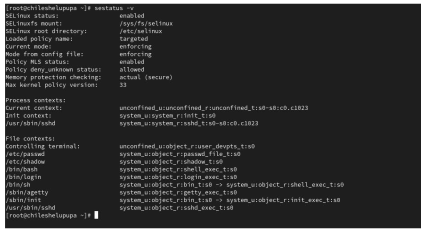

SELinux status: показывает, включена ли SELinux. Current mode: текущий режим (Enforcing, Permissive, Disabled). Policy version: используемая политика безопасности. Loaded policy: загруженный набор правил безопасности. Mode from config file: режим, установленный в конфигурации

## Определение текущего режима работы

Команда getenforce показала Enforcing (принудительный режим).

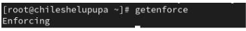

## Изменение режима на Permissive

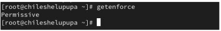

setenforce 0 изменил режим на Permissive. getenforce подтвердил изменение.

## Отключение SELinux через конфигурационный файл

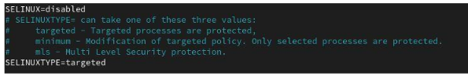

В файле /etc/sysconfig/selinux установлено SELINUX=disabled. После перезагрузки система подтвердила отключение (getenforce вернул Disabled).

## Попытка включения SELinux без перезагрузки

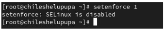

setenforce 1 не сработал, так как отключенный SELinux требует перезагрузки.

## Возвращение режима Enforcing

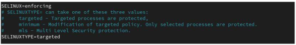

В файле /etc/sysconfig/selinux установлено SELINUX=enforcing. После перезагрузки система запустилась в режиме Enforcing, возможно с предупреждением о необходимости восстановления меток.

# Использование restorecon для восстановления контекста безопасности

## Просмотр контекста файла /etc/hosts

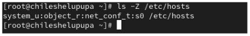

ls -Z /etc/hosts показал net_conf_t.

## Копирование файла и изменение контекста

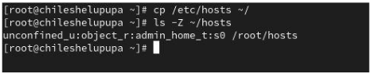

cp /etc/hosts ~/ создал копию с контекстом admin_home_t.

## Перемещение файла обратно и проверка контекста

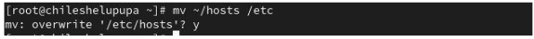

mv ~/hosts /etc сохранило admin_home_t.

## Исправление контекста

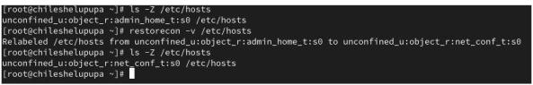

restorecon -v /etc/hosts восстановил net_conf_t.

## Массовое исправление контекста

touch /.autorelabel и перезагрузка инициировали перемаркировку файловой системы

# Настройка контекста для нестандартного расположения веб-файлов

## Установка Apache и текстового браузера

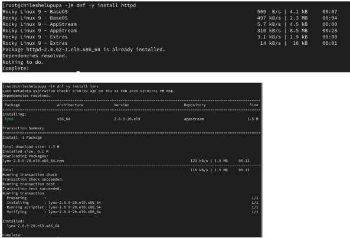

dnf -y install httpd lynx.

## Создание каталога и конфигурация Apache

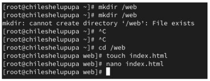

mkdir /web, добавлен index.html.

## В /etc/httpd/conf/httpd.conf изменен DocumentRoot на /web.

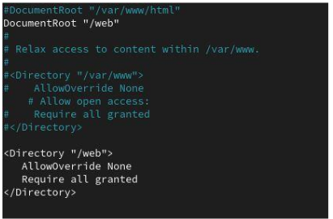

## Запуск Apache и тестирование через lynx

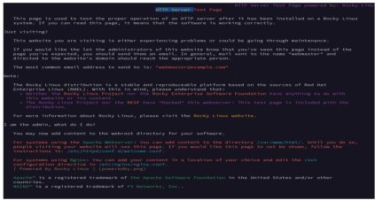

systemctl start httpd, но страница по умолчанию не отображала новый контент.

## Изменение контекста безопасности

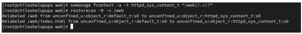

semanage fcontext -a -t httpd_sys_content_t “/web(/.*)?“. restorecon -R -v /web восстановил контекст.

## Повторное тестирование через lynx

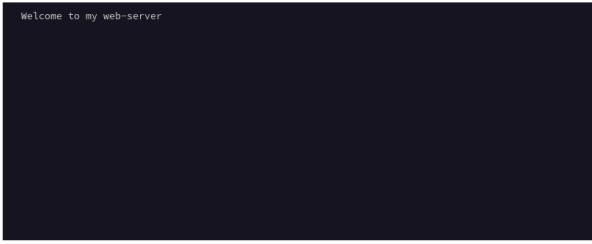

После перезагрузки веб-страница Welcome to my web-server отобразилась успешно.

# Работа с переключателями SELinux

## Просмотр переключателей для FTP

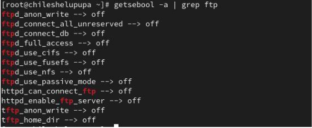

getsebool -a | grep ftp показал ftpd_anon_write off.

## Просмотр переключателей с пояснениями

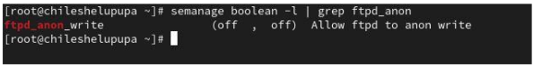

## Установка постоянного значения

setsebool -P ftpd_anon_write on сохранил изменение после перезагрузки.